# Part-1

2026-08-13

## R Markdown

```r
library(Mcomp)
```

```r
library(forecast)
library(ggplot2)
library(fpp2)
library(tseries)
library(smooth)
data<-M3[[1357]]
```

## Data exploration

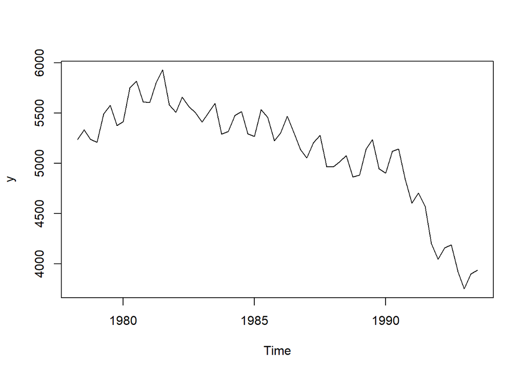

```r
y<-data$x
yout<-data$xx
h<-data$h
plot(y)
```

From the plot we observe a clear downward trend with a quarterly seasonality, while at first sight the data appears to be non-stationary

```r
frequency(y)
```

```
## [1] 4
```

```r
start(y)
```

```
## [1] 1978    2
```

```r
end(y)
```

```
## [1] 1993    3
```

```r
length(y)
```

```
## [1] 62
```

The data is quarterly and starts from the 2nd quarter of 1978 and ends on the 3rd quarter of 1993, with a total of 62 observations.

```r
summary(y)
```

```
##    Min. 1st Qu.  Median    Mean 3rd Qu.    Max.
##    3749    4949    5252    5127    5498    5927
```

```r
sd(y)
```

```
## [1] 520.4523
```

Summary by Quarter

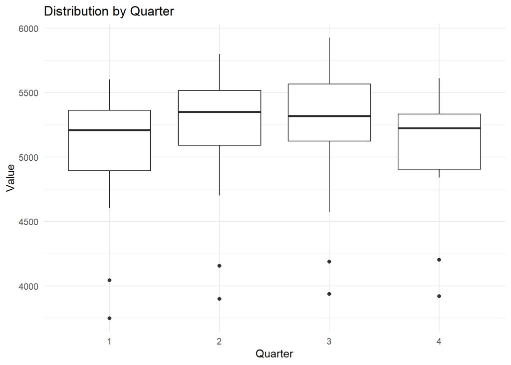

```r
season_df <- data.frame(
  value = as.numeric(y),
  quarter = factor(cycle(y))
)

ggplot(season_df, aes(x = quarter, y = value)) +
  geom_boxplot() +
  labs(
    title = "Distribution by Quarter",
    x = "Quarter",
    y = "Value"
  ) +
  theme_minimal()
```

There seem to be 2 outliers per quarter, which can be explained by the normal line plot of the series, as towards the end of the plot (1992-1993) there is a bigger decline of the data compared to the first years.

### ACF and PACF plots

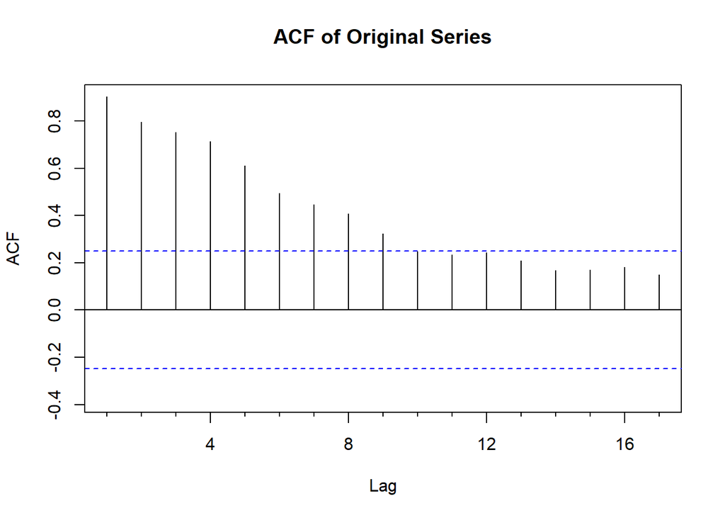

```r
Acf(y, main="ACF of Original Series")
```

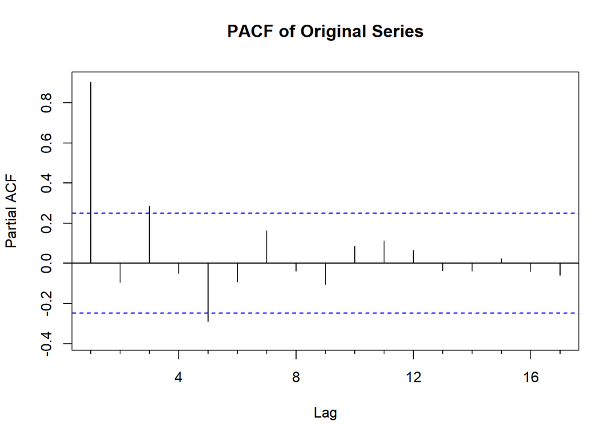

```r
Pacf(y,main = "PACF of Original Series")
```

The plots suggest strong autocorrelation. To confirm that I also ran a Portmanteau test with the null hypothesis being that there is not autocorrelation in the variable:

```r
Box.test(y, lag=1)
```

```
##
##  Box-Pierce test
##
## data:  y
## X-squared = 50.441, df = 1, p-value = 1.228e-12
```

The p-value is much less than 0.05 so we can reject the null hypothesis and assume there is autocorrelation in the data.

Let us now see the ACF and PACF plots of the differenced data :

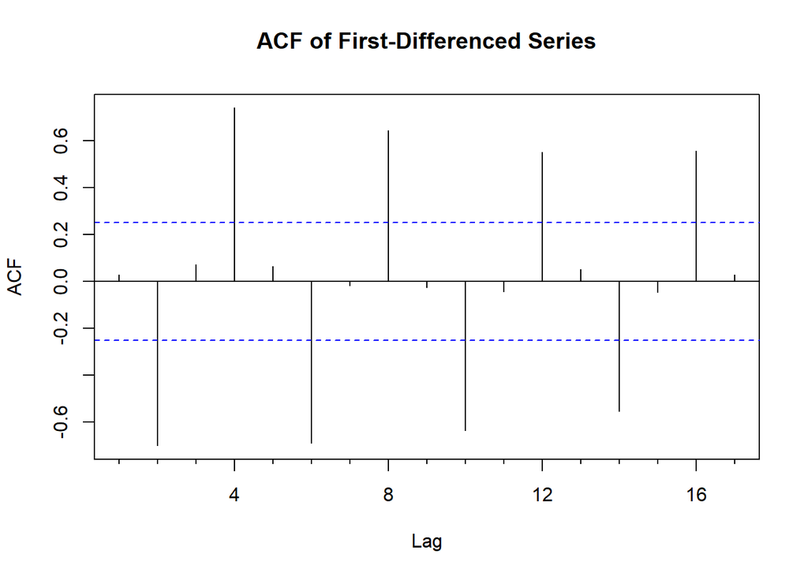

```r
dy<-diff(y)

Acf(dy, main="ACF of First-Differenced Series")
```

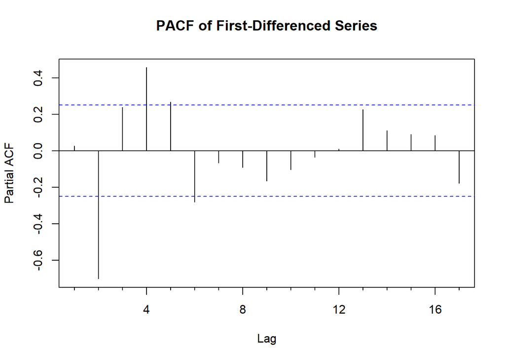

```r
Pacf(dy, main="PACF of First-Differenced Series")
```

The ACF and PACF plots show that seasonal differencing should be taken into consideration. Another way of checking that is to run `nsdiffs` on the differenced data :

```r
nsdiffs(dy)
```

```
## [1] 1
```

```r
dys<-diff(dy,lag=4)
```

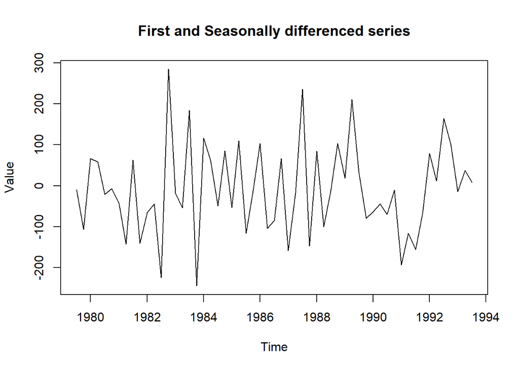

```r
plot(dys, ylab="Value", main="First and Seasonally differenced series")
```

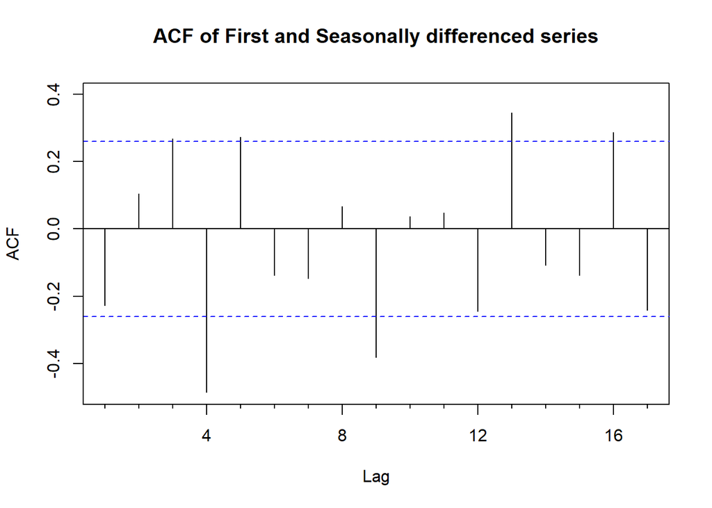

```r
Acf(dys, main="ACF of First and Seasonally differenced series")
```

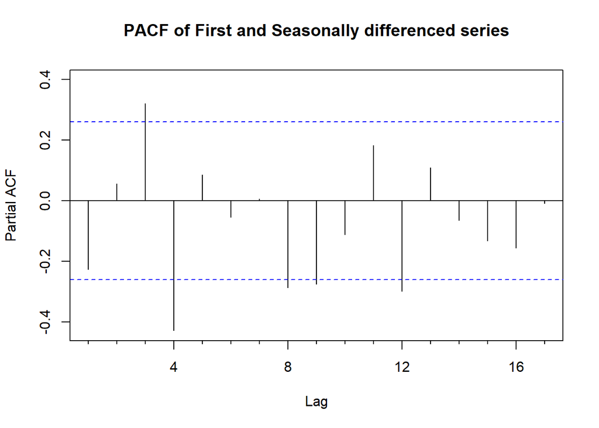

```r
Pacf(dys, main="PACF of First and Seasonally differenced series")
```

After applying a regular and a seasonal difference, the transformed series appears stationary enough for ARIMA modelling. The ACF and PACF of the differenced series do not have a slow decay anymore, so additional differencing is probably unnecessary.We can see that after the seasonal differencing some seasonal effects are still in place, with significant spikes occuring at lags 3,4,5,9,13,16 in the ACF plot, and 3,4,8,9,12 in the PACF plot, indicating that some lag-4 structure remains. The ACF spikes seems more random than the PACF spikes, with the PACF having spikes every 4 lags(4,8,12) plus 2 extra spikes at lag 3 and 9. To keep the degrees of freedom high and the IC low we will only use P=1 (AR(1)) later in modelling.

### Stationarity

The ACF plot above indicates that the data is not stationary, as the the levels of the plot drop below the 95% interval after 9 to 10 lags. However we can perform an Augmented Dickey-Fuller (ADF) test and a Kwiatkowski-Phillips-Schmidt-Shin (KPSS) test to confirm our observations :

```r
adf.test(y, alternative="stationary")
```

```
##
##  Augmented Dickey-Fuller Test
##
## data:  y
## Dickey-Fuller = -1.1964, Lag order = 3, p-value = 0.9
## alternative hypothesis: stationary
```

```r
kpss.test(y)
```

```
##
##  KPSS Test for Level Stationarity
##
## data:  y
## KPSS Level = 1.2537, Truncation lag parameter = 3, p-value = 0.01
```

The ADF test has a p-value of 0.9 meaning that we need to accept the null hypothesis of non-stationarity and the KPSS test has a p-value of less thatn 0.05 showing that we need to reject the null hypothesis of stationarity in the data. Both tests agree that the data is non-stationary which coincides with our observations/conclusion on the ACF plot.

The above observations suggest that transformation and/or differencing should be applied to the data when creating an ARIMA model later on.

### Decomposition

First we will perform classical decomposition :

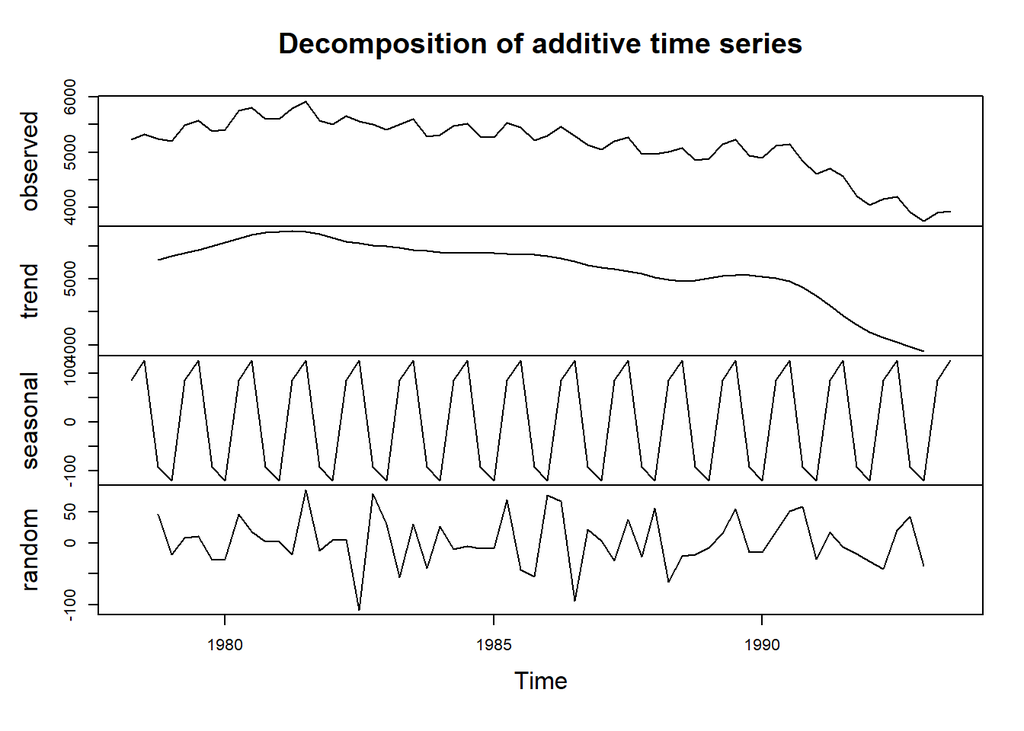

```r
plot(decompose(y, type="additive"))
```

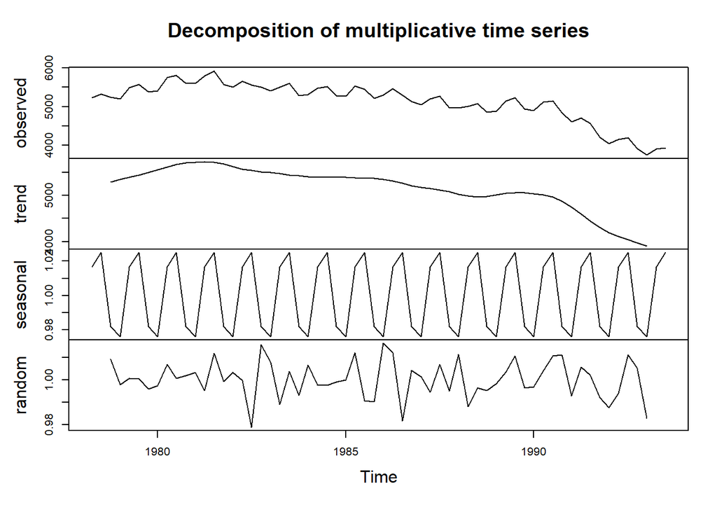

```r
plot(decompose(y, type="multiplicative"))
```

STL decomposition :

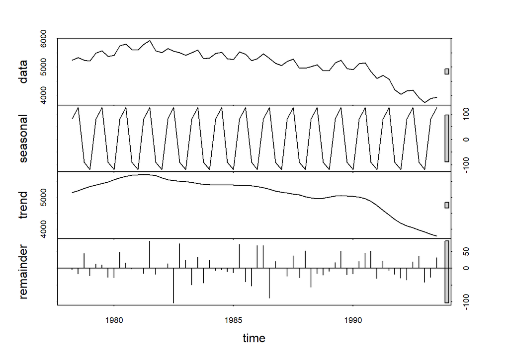

```r
plot(stl(y,s.window="periodic"))
```

### Insights

The series shows a downward trend from the 1980s onward and a strong quarterly seasonal pattern. STL and classical decomposition both confirm that the trend and seasonal components are significant, while the remainder seems to be small compared to the scale of the data.The seasonal component amplitude appears to not change much overtime, suggesting an additive model formulation. The trend history does not give any signs of dampening, therefore we will assume that the apparent recent decline may reflect a temporary change rather than a stable trend that should be damped.

## Modelling

In this section we will fit the data into 3 models, one regression, one ETS and one ARIMA.From the previous exploration of the data, we can assume an additive seasonality and either an additive or damped additive trend.

### Regression

The regression model was specified as a linear trend plus quarterly seasonal dummy variables. The trend term captures the overall long-run movement of the series, while the seasonal dummies capture systematic differences between quarters. Quarter 1 is used as the baseline category, and the remaining three quarter coefficients measure departures from that baseline.

```r
fit_reg<-tslm(y~trend+season)
summary(fit_reg)
```

```
##
## Call:
## tslm(formula = y ~ trend + season)
##
## Residuals:
##    Min     1Q Median     3Q    Max
## -673.1 -160.1  112.3  157.5  347.7
##
## Coefficients:
##             Estimate Std. Error t value Pr(>|t|)
## (Intercept) 5772.577    101.160  57.064  < 2e-16 ***
## trend        -23.685      2.088 -11.342 3.05e-16 ***
## season2      158.538    105.733   1.499   0.1393
## season3      204.722    105.713   1.937   0.0578 .
## season4       26.537    107.425   0.247   0.8058
## ---
## Signif. codes:  0 '***' 0.001 '**' 0.01 '*' 0.05 '.' 0.1 ' ' 1
##
## Residual standard error: 294.1 on 57 degrees of freedom
## Multiple R-squared:  0.7015, Adjusted R-squared:  0.6806
## F-statistic: 33.49 on 4 and 57 DF,  p-value: 2.272e-14
```

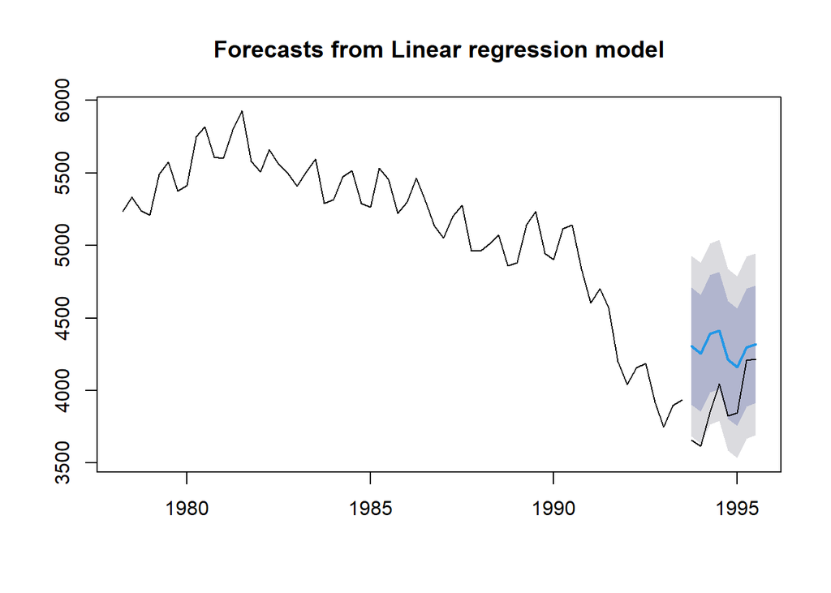

```r
fcs_reg<-forecast(fit_reg, h=h, level=c(80,95)) #forecast the next 8 quarters for confidence intervals of 80% and 95%
plot(fcs_reg)
lines(yout, col="black")
```

#### Residuals

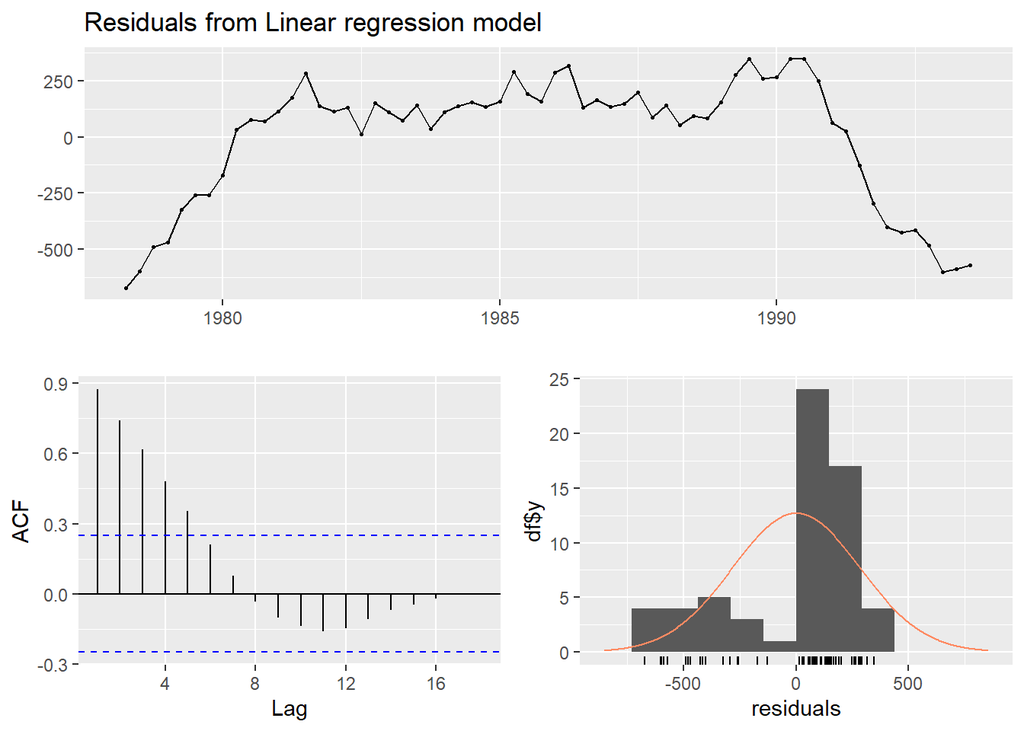

```
##
##  Breusch-Godfrey test for serial correlation of order up to 8
##
## data:  Residuals from Linear regression model
## LM test = 51.795, df = 8, p-value = 1.843e-08
```

```r
res_reg <- residuals(fit_reg)

checkresiduals(fit_reg)
```

The residuals plot shows long runs of positive and negative erros instead of a random fluctuation around 0. Residuals are negative at the beginning and the end of the plot, while they remain positive in the middle. This means that a linear model is to simple to capture the behavior of the data. The ACF plot show strong autocorrelation, which means that the model has failed to capture temporal information. We can also run numerical tests on the residuals to confirm the over-simplicity of the model.

Ljung-Box test null hypothesis is that the residuals are independently distributed, while the shapiro test assumes normal distribution of errors.

```r
Box.test(res_reg, type="Ljung-Box")
```

```
##
##  Box-Ljung test
##
## data:  res_reg
## X-squared = 49.597, df = 1, p-value = 1.888e-12
```

```r
shapiro.test(res_reg)
```

```
##
##  Shapiro-Wilk normality test
##
## data:  res_reg
## W = 0.84177, p-value = 1.277e-06
```

As both p-values are less than 0.05, we have to reject their null hypotheses. This violates the normality and independence of errors in the L-I-N-E assumptions for linear regression.

#### Parameters

```r
summary(fit_reg)
```

```
##
## Call:
## tslm(formula = y ~ trend + season)
##
## Residuals:
##    Min     1Q Median     3Q    Max
## -673.1 -160.1  112.3  157.5  347.7
##
## Coefficients:
##             Estimate Std. Error t value Pr(>|t|)
## (Intercept) 5772.577    101.160  57.064  < 2e-16 ***
## trend        -23.685      2.088 -11.342 3.05e-16 ***
## season2      158.538    105.733   1.499   0.1393
## season3      204.722    105.713   1.937   0.0578 .
## season4       26.537    107.425   0.247   0.8058
## ---
## Signif. codes:  0 '***' 0.001 '**' 0.01 '*' 0.05 '.' 0.1 ' ' 1
##
## Residual standard error: 294.1 on 57 degrees of freedom
## Multiple R-squared:  0.7015, Adjusted R-squared:  0.6806
## F-statistic: 33.49 on 4 and 57 DF,  p-value: 2.272e-14
```

The seasonal effects are comparatively weak with Quarter 3 having the largest estimated positive difference relative to Quarter 1, at 204.7 units. However, this effect is marginally significant with a p-value of 0.0578.

The regression model shows a downward trend but limited evidence that the quarterly seasonal effects differ systematically from the first quarter.

The model’s explained variation is at 70.2%, while after adjusting for the number of predictors it explains 68.1%.

With the p-value of the F-statistic being much lower than 0.05, we can conclude that the variables are jointly useful.

### ETS

From the decomposition performed previously, we concluded that an additive model may be adequate for ETS modelling, as the seasonal component seems approximately constant rather than varying with time. We will try an additive model :

```r
fit_aaa <- ets(y, model = "AAA", damped=FALSE)
summary(fit_aaa)
```

```
## ETS(A,A,A)
##
## Call:
## ets(y = y, model = "AAA", damped = FALSE)
##
##   Smoothing parameters:
##     alpha = 0.9593
##     beta  = 0.1006
##     gamma = 1e-04
##
##   Initial states:
##     l = 5586.4121
##     b = 57.7233
##     s = -127.781 -87.4741 143.0486 72.2066
##
##   sigma:  108.0532
##
##      AIC     AICc      BIC
## 845.9623 849.4238 865.1065
##
## Training set error measures:
##                     ME     RMSE      MAE        MPE     MAPE      MASE
## Training set -20.13477 100.8413 68.92353 -0.4020671 1.350054 0.3842397
##                     ACF1
## Training set -0.02689764
```

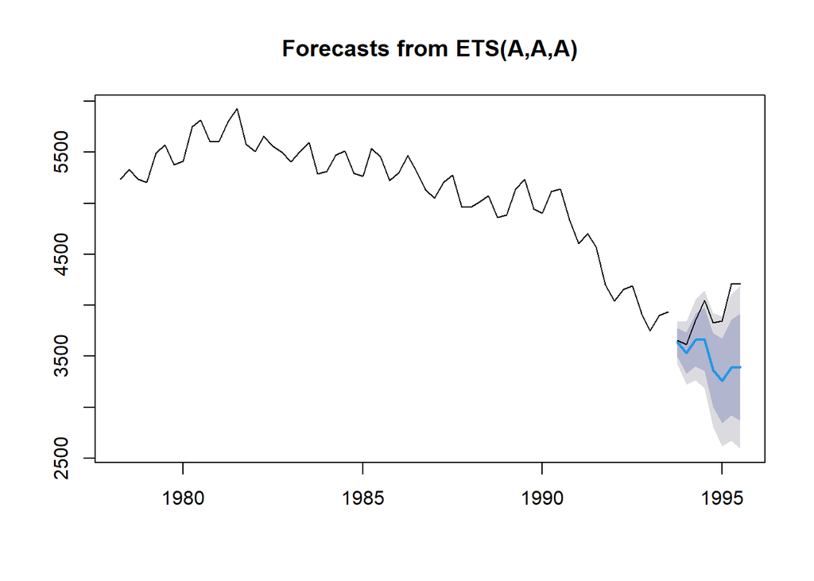

```r
#Forecasts
fcs_aaa<-forecast(fit_aaa, h=h, level=c(80,95))
plot(fcs_aaa)
lines(yout, col="black")
```

#### Residuals

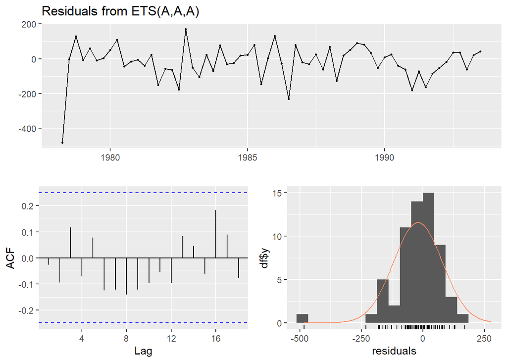

```
##
##  Ljung-Box test
##
## data:  Residuals from ETS(A,A,A)
## Q* = 5.9302, df = 8, p-value = 0.6551
##
## Model df: 0.   Total lags used: 8
```

```r
checkresiduals(fit_aaa)
```

We can again run a Shapiro-Wilk and Ljung Box test to confirm our observations:

```r
res_aaa<-residuals(fit_aaa)
Box.test(res_aaa, type="Ljung-Box")
```

```
##
##  Box-Ljung test
##
## data:  res_aaa
## X-squared = 0.047062, df = 1, p-value = 0.8283
```

```r
shapiro.test(res_aaa)
```

```
##
##  Shapiro-Wilk normality test
##
## data:  res_aaa
## W = 0.88661, p-value = 3.385e-05
```

The Ljung Box test shows there is no autocorrelation while the Shapiro-Wilk test shows non-normal errors.

#### Parameters

```r
summary(fit_aaa)
```

```
## ETS(A,A,A)
##
## Call:
## ets(y = y, model = "AAA", damped = FALSE)
##
##   Smoothing parameters:
##     alpha = 0.9593
##     beta  = 0.1006
##     gamma = 1e-04
##
##   Initial states:
##     l = 5586.4121
##     b = 57.7233
##     s = -127.781 -87.4741 143.0486 72.2066
##
##   sigma:  108.0532
##
##      AIC     AICc      BIC
## 845.9623 849.4238 865.1065
##
## Training set error measures:
##                     ME     RMSE      MAE        MPE     MAPE      MASE
## Training set -20.13477 100.8413 68.92353 -0.4020671 1.350054 0.3842397
##                     ACF1
## Training set -0.02689764
```

Level smoothing parameter α is 0.9593, which means that the estimated level reacts strongly to more recent observations

Trend smoothing parameter β is 0.1006, which means that the model does not change its estimated trend/direction in response to every new observation.

Seasonality smoothing parameter γ is 0.0001, which means that the quarterly seasonal patter is fixed over time. The model detects an optimal seasonal pattern and tries to keep it stable - consistent with earlier observation of seasonal effects not changing over time.

### ARIMA

As discussed previously, an ARIMA model of (0,1,0)(1,1,0)4 will be fitted in the series.

```r
fit_arima<-Arima(y, order=c(0,1,0), seasonal=list(order=c(1,1,0), period=4))
summary(fit_arima)
```

```
## Series: y
## ARIMA(0,1,0)(1,1,0)[4]
##
## Coefficients:
##          sar1
##       -0.4619
## s.e.   0.1128
##
## sigma^2 = 9676:  log likelihood = -342.41
## AIC=688.81   AICc=689.03   BIC=692.9
##
## Training set error measures:
##                     ME     RMSE      MAE        MPE     MAPE      MASE
## Training set -13.01308 93.48788 74.46633 -0.2453708 1.462418 0.4151401
##                    ACF1
## Training set -0.0404904
```

```r
fcs_arima<-forecast(fit_arima, h=h, levels=c(80,95))
```

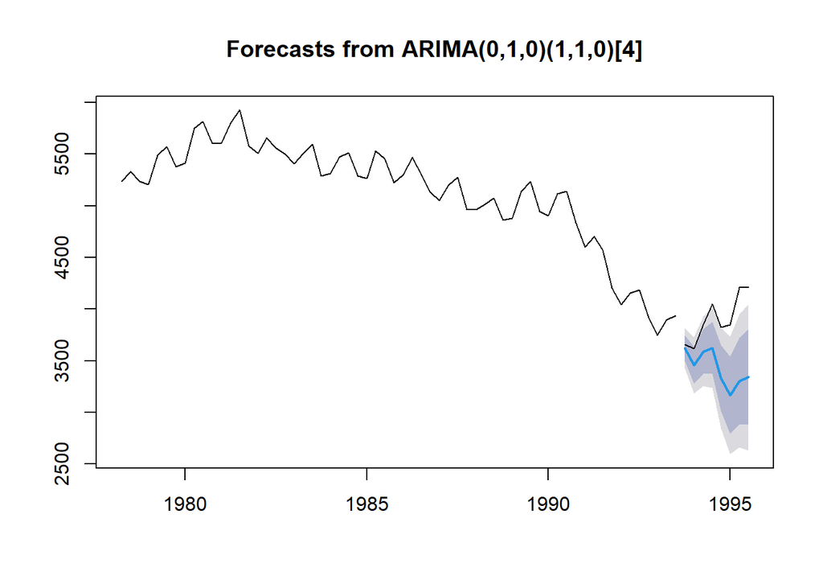

```r
plot(fcs_arima)
lines(yout, col="black")
```

#### Residuals

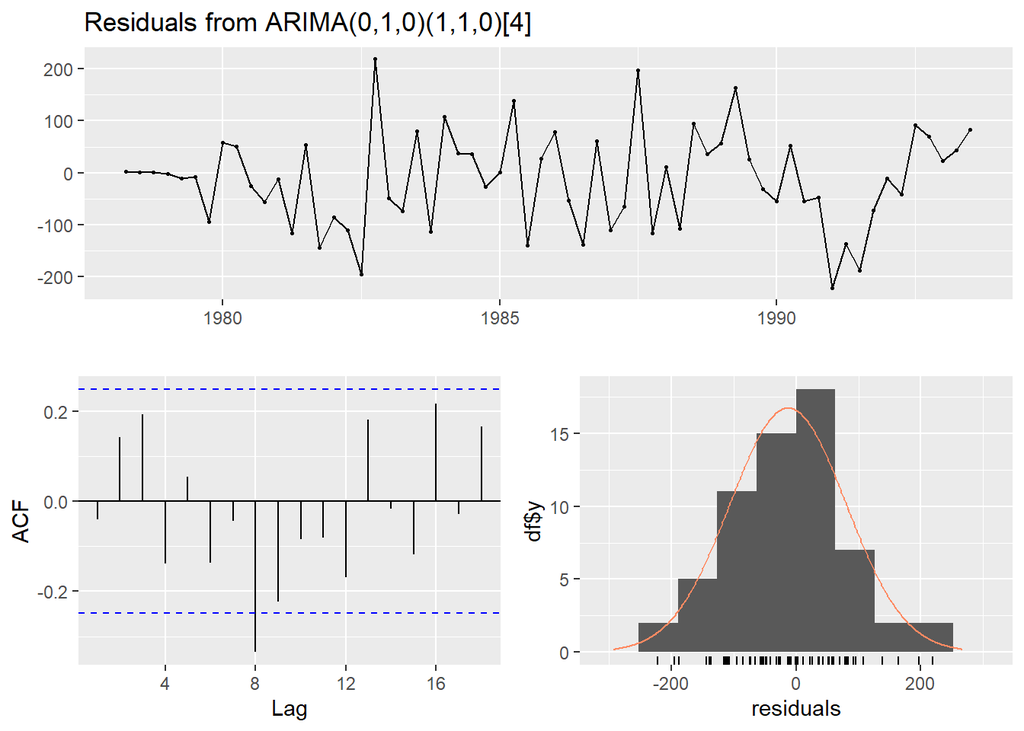

```
##
##  Ljung-Box test
##
## data:  Residuals from ARIMA(0,1,0)(1,1,0)[4]
## Q* = 15.188, df = 7, p-value = 0.03367
##
## Model df: 1.   Total lags used: 8
```

```r
checkresiduals(fit_arima)
```

```r
res_arima<-residuals(fit_arima)
Box.test(res_arima, type="Ljung-Box")
```

```
##
##  Box-Ljung test
##
## data:  res_arima
## X-squared = 0.10665, df = 1, p-value = 0.744
```

```r
shapiro.test(res_arima)
```

```
##
##  Shapiro-Wilk normality test
##
## data:  res_arima
## W = 0.99126, p-value = 0.9396
```

#### Parameters

```r
summary(fit_arima)
```

```
## Series: y
## ARIMA(0,1,0)(1,1,0)[4]
##
## Coefficients:
##          sar1
##       -0.4619
## s.e.   0.1128
##
## sigma^2 = 9676:  log likelihood = -342.41
## AIC=688.81   AICc=689.03   BIC=692.9
##
## Training set error measures:
##                     ME     RMSE      MAE        MPE     MAPE      MASE
## Training set -13.01308 93.48788 74.46633 -0.2453708 1.462418 0.4151401
##                    ACF1
## Training set -0.0404904
```

### Model Comparison on Test Data

#### Forecast Errors

For the model comparison, Root Mean Squared Error will be used. It is meaningful in this case as it measures the typical forecast error in the original units.

```r
accuracy_results <- data.frame(
  Model = c("Regression", "ETS", "ARIMA"),
  RMSE = c(
    sqrt(mean((yout - fcs_reg$mean)^2)),
    sqrt(mean((yout - fcs_aaa$mean)^2)),
    sqrt(mean((yout - fcs_arima$mean)^2))
  ),
  MAE = c(
    mean(abs(yout - fcs_reg$mean)),
    mean(abs(yout - fcs_aaa$mean)),
    mean(abs(yout - fcs_arima$mean))
  )
)

accuracy_results
```

```
##        Model     RMSE      MAE
## 1 Regression 436.5252 385.9760
## 2        ETS 512.6402 421.9717
## 3      ARIMA 565.6920 478.4597
```

Point forecasts :

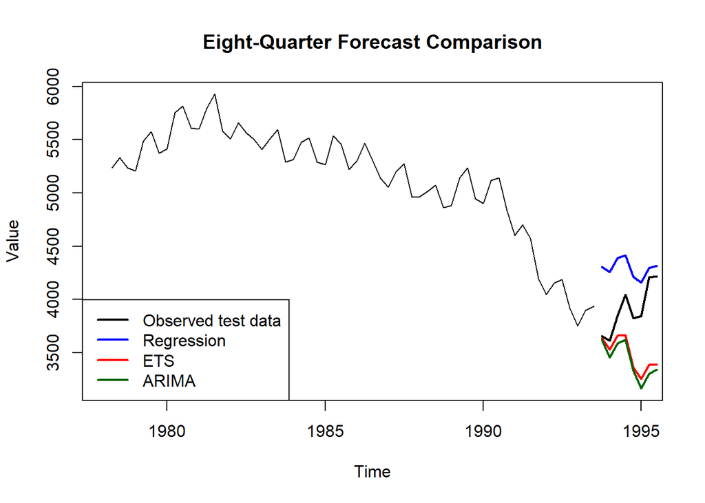

```r
plot(
  y,
  xlim = c(start(y)[1], end(y)[1] + 2),
  ylim = range(c(y, yout, fcs_reg$mean, fcs_aaa$mean, fcs_arima$mean)),
  main = "Eight-Quarter Forecast Comparison",
  ylab = "Value",
  xlab = "Time"
)

lines(fcs_reg$mean, col = "blue", lwd = 2)
lines(fcs_aaa$mean, col = "red", lwd = 2)
lines(fcs_arima$mean, col = "darkgreen", lwd = 2)
lines(yout, col = "black", lwd = 2)

legend(
  "bottomleft",
  legend = c("Observed test data", "Regression", "ETS", "ARIMA"),
  col = c("black", "blue", "red", "darkgreen"),
  lty = 1,
  lwd = 2
)
```

The regression model produced the lowest RMSE on the 8 quarter horizon, at 437 compared with the 512 for ETS(A,A,A) and 566 for ARIMA. The regression model provided the most accurate forecasts for this validation period, meaning that the continuation of the estimated linear trend and quarterly seasonal patter was more useful for forecasting at this horizon than dynamic models such as ETS and ARIMA.